# ARIMA_MODEL

20MIA1081_20MIA1122

2024-03-05

```r
library(forecast)
library(tseries)
btc_data <- read.csv("C://Users//kumar//OneDrive//Documents//BTC-USD (1).csv")
btc_data$Date <- as.Date(btc_data$Date)
btc_data <- na.omit(btc_data)  # Remove NA values
```

```r
btc_data$Close <- as.numeric(as.character(btc_data$Close))
```

```r
# Ensure the 'tseries' package is loaded
library(tseries)

# Remove NA values from your data
btc_data <- na.omit(btc_data)

# Convert 'Close' to numeric if it's not already
btc_data$Close <- as.numeric(btc_data$Close)

# Now run the ADF test
adf_test_result <- adf.test(btc_data$Close, alternative = "stationary")
# Print the result
print(adf_test_result)
```

```
##
##  Augmented Dickey-Fuller Test
##
## data:  btc_data$Close
## Dickey-Fuller = 1.301, Lag order = 7, p-value = 0.99
## alternative hypothesis: stationary
```

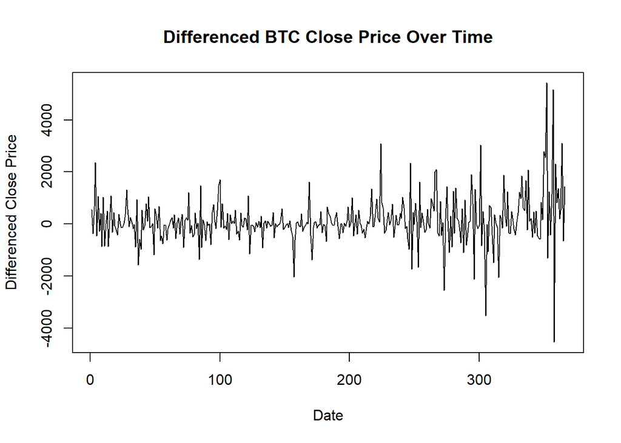

```r
btc_diff <- diff(btc_data$Close, differences = 1)
plot(btc_diff, type="l", xlab="Date", ylab="Differenced Close Price", main="Differenced BTC Close Price Over Time")
```

The graph in the image shows the differenced closing prices of Bitcoin (BTC) over time.

The graph is plotting changes in the closing price of Bitcoin from one time point to the next. It is not the actual price but the difference from one price to the next. For instance, if the closing price of Bitcoin was $10,000 one day and $10,050 the next, the differenced price would be $50 for that day.

The negative values indicate days where the closing price of Bitcoin was lower than the previous day. A negative differenced value means the price dropped. Conversely, positive values would indicate days where the price increased compared to the previous day.

positive and negative values is normal in financial data, reflecting the day-to-day volatility and price changes in the cryptocurrency market. The graph helps to visualize this volatility and is often used to prepare the data for further analysis, such as predicting future prices using statistical models.

```r
auto_fit <- auto.arima(btc_data$Close, seasonal = FALSE)  # Set seasonal=FALSE for non-seasonal data
summary(auto_fit)
```

```
## Series: btc_data$Close
## ARIMA(0,2,3)
##
## Coefficients:
##           ma1     ma2      ma3
##       -1.1175  0.2660  -0.1086
## s.e.   0.0521  0.0759   0.0521
##
## sigma^2 = 793320:  log likelihood = -2996.81
## AIC=6001.61   AICc=6001.72   BIC=6017.21
##
## Training set error measures:
##                    ME     RMSE      MAE        MPE     MAPE      MASE
## Training set 27.79279 884.5969 556.4818 0.01527756 1.549712 0.9866494
##                     ACF1
## Training set -0.00317127
```

```r
arima_fit <- arima(btc_data$Close, order = c(auto_fit$arma[1], auto_fit$arma[6], auto_fit$arma[2]))
```

#The table represents the forecasted values from an ARIMA model, along with the associated prediction intervals for those forecasts:

#Lo 80 and Hi 80: These columns give the lower and upper bounds of an 80% prediction interval. This means that there is an 80% probability that the true future value will fall within this range. A narrower interval indicates more certainty in the predictions.

#Lo 95 and Hi 95: Similarly, these columns provide the lower and upper bounds of a 95% prediction interval. There is a 95% probability that the true future value will fall within this range. The 95% interval is wider than the 80% interval, reflecting the increased certainty that the future value will lie within it.

#The widening of the prediction intervals as you go further into the future (noticed by the increasing distance between the lower and upper bounds) represents increasing uncertainty in the forecast the further out you go. This is typical for most time series forecasts - the longer the forecast horizon, the less certain the model is about the prediction, which is reflected in wider confidence intervals.

```r
future_steps <- 30  # For example, forecast the next 30 days
forecasted_values <- forecast(arima_fit, h = future_steps)
forecasted_values
```

```
##     Point Forecast    Lo 80     Hi 80    Lo 95     Hi 95
## 368       73464.64 72327.88  74601.39 71726.12  75203.16
## 369       74196.95 72680.80  75713.10 71878.20  76515.70
## 370       74891.66 72975.27  76808.05 71960.80  77822.53
## 371       75586.37 73315.95  77856.80 72114.05  79058.70
## 372       76281.09 73683.07  78879.11 72307.76  80254.42
## 373       76975.80 74066.97  79884.62 72527.13  81424.46
## 374       77670.51 74462.14  80878.88 72763.73  82577.29
## 375       78365.22 74865.09  81865.35 73012.23  83718.21
## 376       79059.93 75273.48  82846.39 73269.05  84850.82
## 377       79754.65 75685.65  83823.64 73531.65  85977.64
## 378       80449.36 76100.39  84798.33 73798.19  87100.53
## 379       81144.07 76516.79  85771.35 74067.26  88220.88
## 380       81838.78 76934.15  86743.41 74337.79  89339.77
## 381       82533.49 77351.91  87715.07 74608.95  90458.03
```

[output cut: 16 more lines]

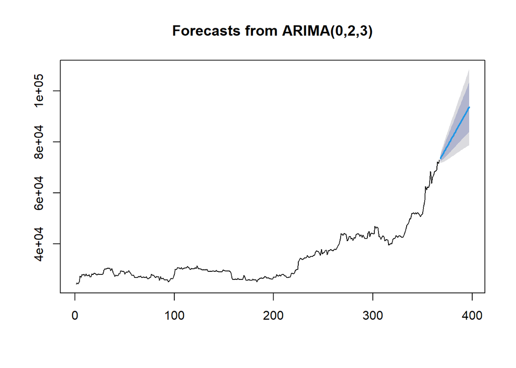

```r
plot(forecasted_values)
```